# Assignment 4 (Part 1)

202120187

10 January 2024

My public Github repository for this assignment can be found at https://github.com/wwong20/my472-assignment4.

## Introduction

For this assignment, I chose to analyse Option 1, to find out if there are indeed biases in the individuals chosen by the police to conduct stop and search.

In the United Kingdom, there have been reports by the [BBC](https://www.bbc.co.uk/news/uk-61167875) and [The Guardian](https://www.theguardian.com/uk-news/2022/apr/20/police-watchdog-ethnic-minorities-need-protection-from-unfair-stop-and-search) alleging that Black, Asian, and mixed ethnic people were 2.5 to 7 times more likely to be stopped and searched by the police. The Independent Office for Police Conduct [(IPOC)](https://www.policeconduct.gov.uk/news/iopc-calls-stop-and-search-law-change-and-identifies-18-opportunities-improvement) also made recommendations to the police forces to develop guidelines to safeguard ethnic minorities from experiencing disproportionate use of force during stops and searches due to stereotypical assumptions and biases affecting the policing response.

Thus, I will focus on whether there is a bias in the ethnicity of individuals stopped by police forces for searches.

## Data

```
## [1] 44
```

Output 1: The number of police forces in the UK, excluding BTP

```
## [1] "2020-12" "2021-01" "2021-02" "2021-03" "2021-04" "2021-05"
```

```
## [1] "2023-06" "2023-07" "2023-08" "2023-09" "2023-10" "2023-11"
```

Output 2: The outputs above show the head and tail of dates (i.e. start and end) available for the API data.

From the police’s availability API data, the most complete data (for 41 of the 45 police forces) was available from December 2020 to April 2022. Official statistics by the UK government often end the year in March, and to minimize confounding variables such as seasonality to crime, I analysed the data from April 2021 to March 2022.

Data for the following police forces were unavailable and thus not included in this analyses:

```
## [1] "greater-manchester" "gwent"              "north-yorkshire"
## [4] "northern-ireland"
```

Output 3: Police forces which API data was not available for during the period of April 2021 to March 2022

The necessary data sets were obtained via the police API, and only scraped if it doesn’t already exist in the R global environment to reduce load on the servers.

My analysis focused on “officer-defined-ethnicity”, as I wanted to focus on the officers’ presumption of an individual’s ethnicity, and not the individual’s perspective of being discriminated against.

To clean the data, all instances where relevant data was blank or ‘NA’ were excluded from the analyses.

For better analysis of the data, data from the [UK 2021 Census](https://www.ethnicity-facts-figures.service.gov.uk/uk-population-by-ethnicity/national-and-regional-populations/population-of-england-and-wales/latest/#data-sources) was used to obtain the proportion of each ethnicity in the UK in 2021:

```
##   Time Ethnicity Value Value_type
## 1 2021       All 100.0          %
## 2 2021     Asian   9.3          %
## 3 2021     Black   4.0          %
## 4 2021     Mixed   2.9          %
## 5 2021     White  81.7          %
## 6 2021     Other   2.1          %
```

Output 4: UK 2021 Census ethnic proportions

## Analysis

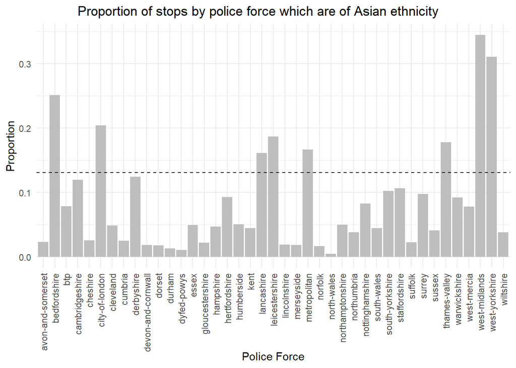

Graph 1: Proportion of stops by police force on individuals of Asian ethnicity

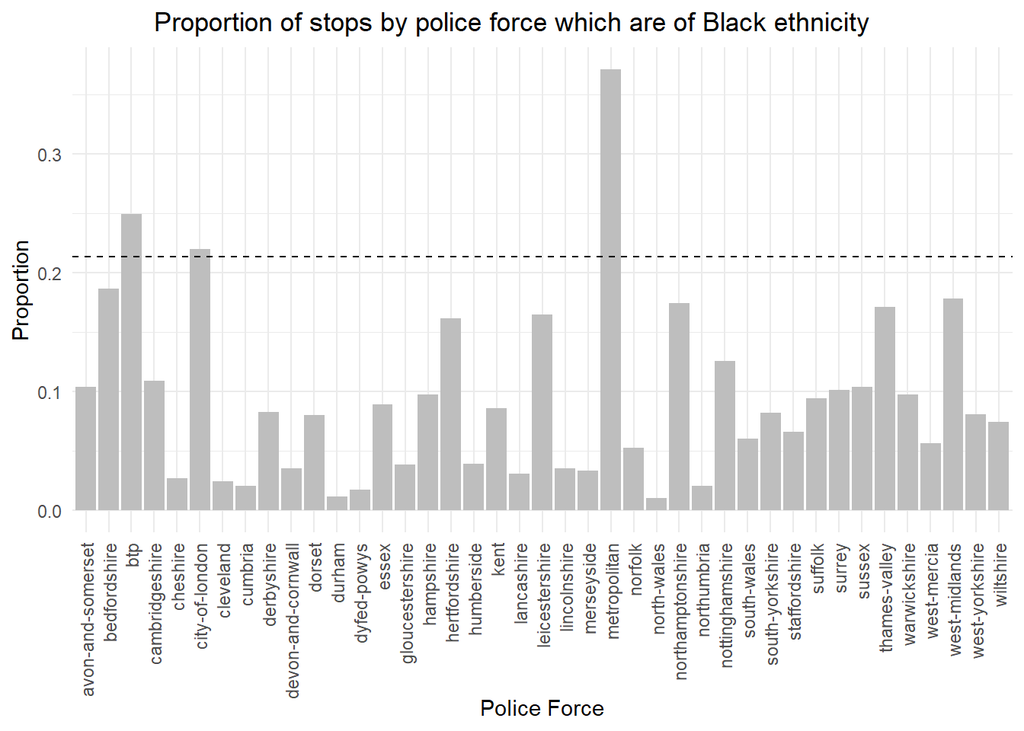

Graph 2: Proportion of stops by police force on individuals of Black ethnicity

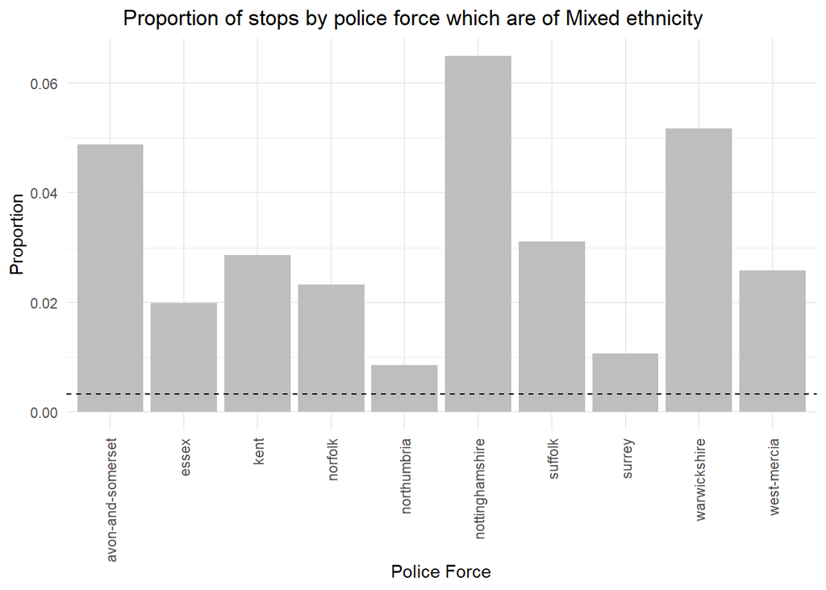

Graph 3: Proportion of stops by police force on individuals of Mixed ethnicity

The low proportion of stops for Mixed ethnicities could be because it is difficult for officers to identify immediately if an individual is so, but might classify them under another or “Other” ethnicity.

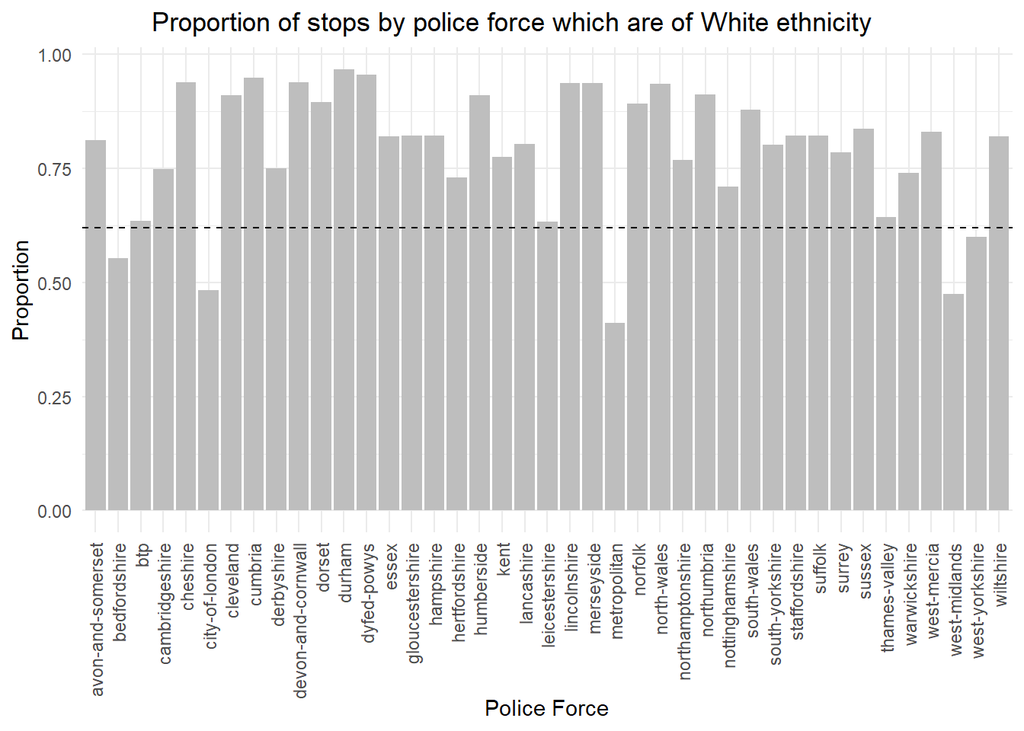

Graph 4: Proportion of stops by police force on individuals of White ethnicity

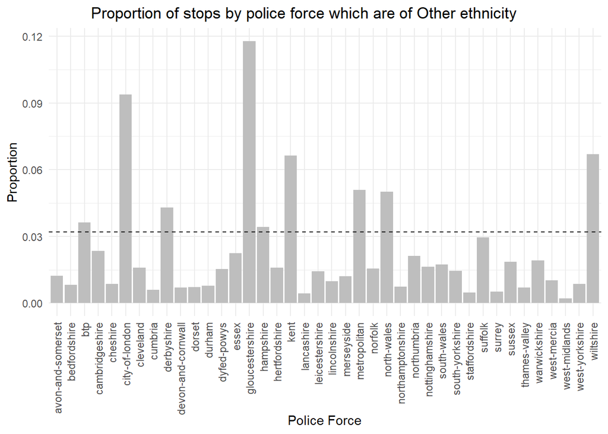

Graph 5: Proportion of stops by police force on individuals of Other ethnicity

From the above graphs and Output 4, we can see that:

- Asian: 9.3% of population, 13.08% of stop and searches
- Black: 4.0% of population, 21.37% of stop and searches
- Mixed: 2.9% of population, 0.32% of stop and searches
- White: 81.7% of population, 62.01% of stop and searches
- Other: 2.1% of population, 3.21% of stop and searches

Minority ethnicities make up only 18.3% of the entire UK population but account for over double (37.99%) the proportion of all stop and searches. Specifically, 21.37% of stop and searches are conducted on Black people when they only make up 4.0% of the population. This highlights that minority ethnicities, especially Black people, are stopped and searched by the police forces disproportionately.

However, there may be arguments that this may be due to the fact that minorities may commit more crimes and thus are more likely to be stop, searched, and arrested. The [UK Government)](https://www.ethnicity-facts-figures.service.gov.uk/crime-justice-and-the-law/policing/number-of-arrests/latest/) hast stated that Black people have the almost double the arrest rate per 1,000 people.

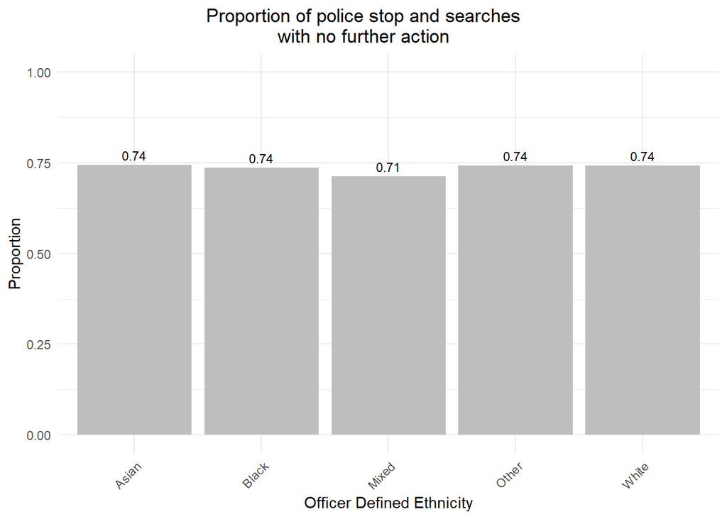

Graph 6: Proportion of police stop and searches by ethnicity with no further action taken

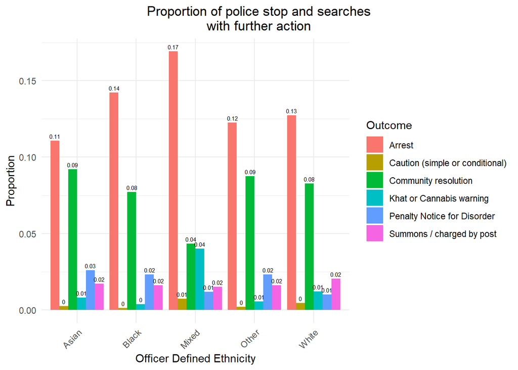

Graph 7: Proportion of police stop and searches by ethnicity with further action taken

From Graph 6, we see that no further action is taken for most stop and searches, and this proportion is similar across all ethnicities.

The proportion of arrests across ethnicities are also mostly similar.

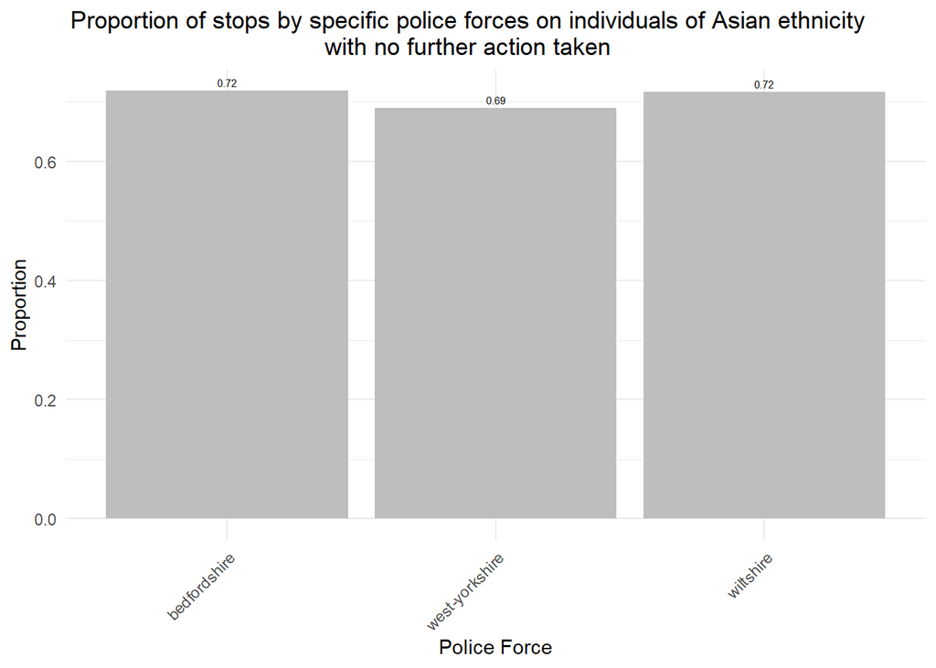

Graph 8: Proportion of stops by specific police forces on individuals of Asian ethnicity with no further action taken

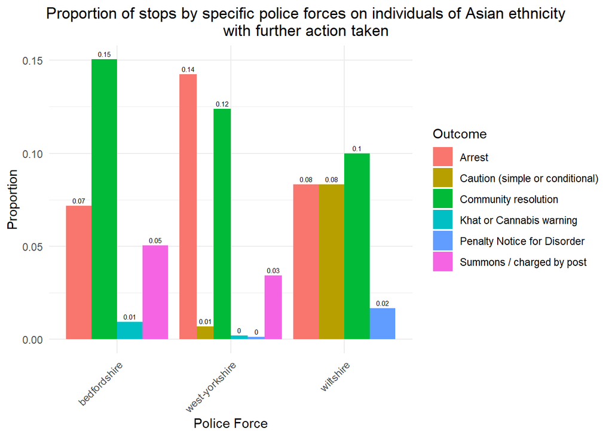

Graph 9: Proportion of stops by specific police forces on individuals of Asian ethnicity with further action taken

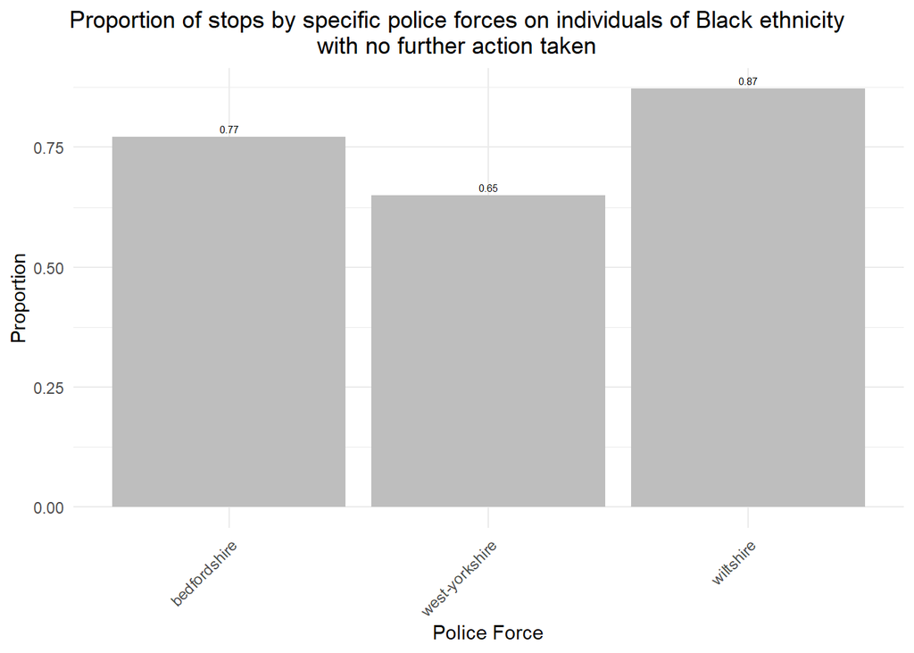

Graph 10: Proportion of stops by specific police forces on individuals of Black ethnicity with no further action taken

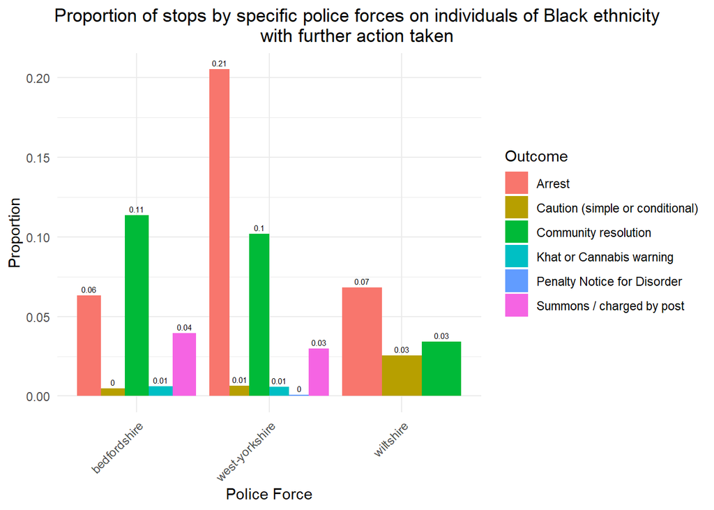

Graph 11: Proportion of stops by specific police forces on individuals of Black ethnicity with further action taken

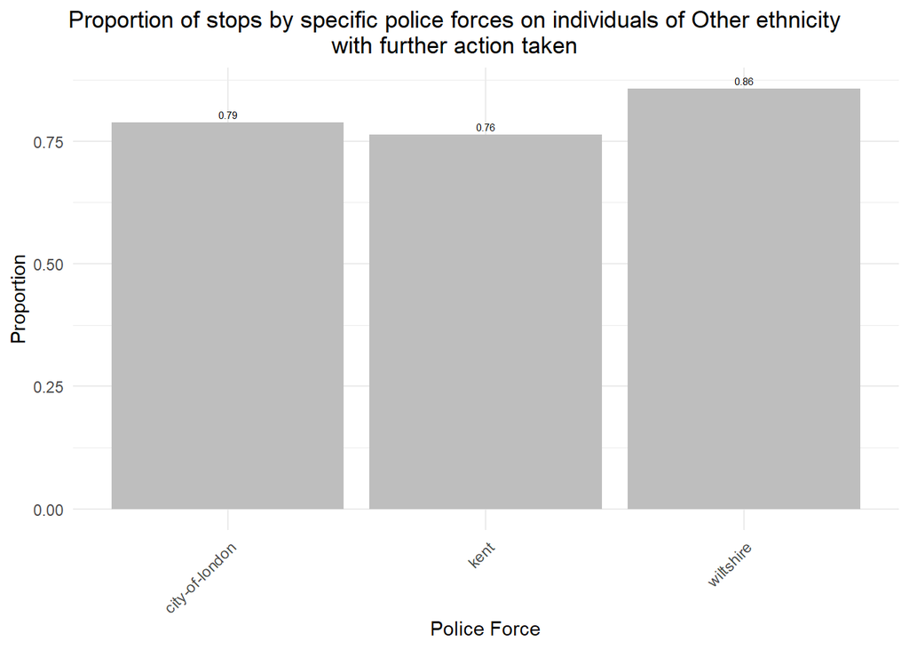

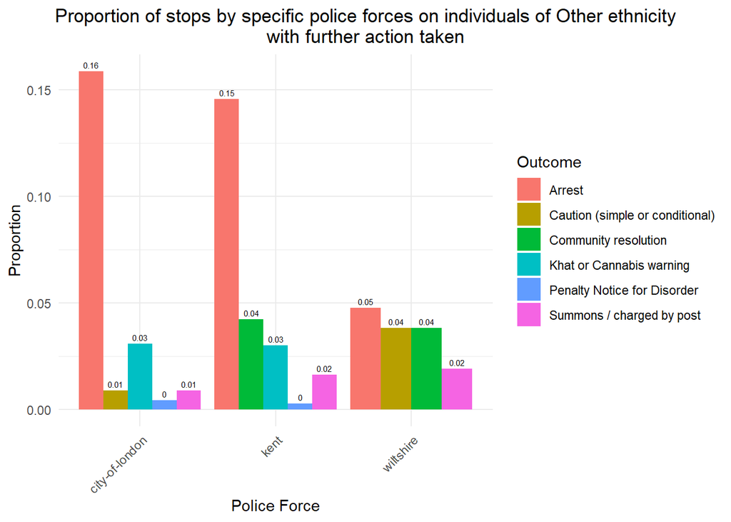

Graph 13: Proportion of stops by specific police forces on individuals of Other ethnicity with further action taken

From Graphs 8, 10, and 12, we can see that in general, the proportions of stop and searches lead to similar proportions of outcomes where there are no further actions taken against the individuals.

In Graph 11, we can see that although the proportions of stops leading to arrests against Black people in West Yorkshire are slightly higher, they are significantly much lower in the other two police jurisdictions.

In conclusion, there is definitely a bias against ethnic minorities, especially Black people, with regard to stop and searches. As these stop and searches do not lead to significant increases in the proportion of arrests, the police forces should work on the recommendations of the IPOC to reduce and minimize such biases.

## Code Appendix

```r
# this chunk contains code that sets global options for the entire .Rmd.
# we use include=FALSE to suppress it from the top of the document, but it will still appear in the appendix.

knitr::opts_chunk$set(echo = FALSE) # actually set the global chunk options.
# we set echo=FALSE to suppress code such that it by default does not appear throughout the document.
# note: this is different from .Rmd default

library(jsonlite)
library(dplyr)
library(ggplot2)
library(tidyverse)


# Obtaining the list of police forces in the UK via API
api_forces <- fromJSON("https://data.police.uk/api/forces")


# Obtaining the total number of police forces in the UK
print(nrow(api_forces))


# Obtaining the list of available data sets via API
data_availability <- fromJSON("https://data.police.uk/api/crimes-street-dates")

# Reversing the order of the rows into chronological order
data_availability <- data_availability[rev(1:nrow(data_availability)),]


# Show the range of dates where police data is available
print(head(data_availability$date))
print(tail(data_availability$date))


# Check if data available for police forces for a particular month is same as the previous month's
data_availability$is_duplicate <- mapply(identical, data_availability$`stop-and-search`, lag(data_availability$`stop-and-search`))
rownames(data_availability) <- NULL

# List of all police forces including the BTP
all_forces <- c(api_forces$id, "btp")

# List of police forces where data is available for April 2021 to March 2022
data_availability
available_forces <- data_availability[[2, 2]]

# List of police forces where data is not available for April 2021 to March 2022
excluded_forces <- all_forces[!all_forces %in% available_forces]
excluded_forces


web_scraping <- function() {

  # Assigning the base URL for web scraping
  base_url <- "https://data.police.uk/api/stops-force?force="

  # Assigning empty data frame to include web scraping data
  raw_data <- data.frame()

  # Looping the function across the 41 police forces
  for (i in seq_along(available_forces)) {
    force_urls <- c()

    # Looping the function over the analysis time period for each police force
    for (j in 5:16) {

      # Generating the URL for each police force at each month
      url <- paste0(base_url, available_forces[i], "&date=", data_availability$date[j])

      # Adding the URL to a vector
      force_urls <- c(force_urls, url)
    }

    # Assigning a temporary data frame to hold the scraped data
    temp_data <- data.frame()

    # Looping the web scraping through all the URLs
    for (k in force_urls) {
      scraped_data <- fromJSON(k)

      # Binding the newly scraped data to previously scraped data
      temp_data <- bind_rows(temp_data, scraped_data)
    }

    # Adding a column identifying the police force it belongs to and merging all the data together
    temp_data$police_force <- available_forces[i]
    raw_data <- bind_rows(raw_data, temp_data)
  }

  # Saving the data in the R global environment
  assign("raw_data", raw_data, envir = .GlobalEnv)
}


# Only web scrape when the data doesn't already exist in the global environment
if (!exists("raw_data")) {
  web_scraping()
}

# Only includes cases where ethnicity is defined
clean_data <- raw_data %>%
  filter(complete.cases(officer_defined_ethnicity))


# Obtain the proportions each ethnicity is stopped by each police force
ethnic_proportions <- clean_data %>%
  group_by(police_force) %>%
  count(officer_defined_ethnicity, name = "count") %>%
  mutate(proportion = count / sum(count)) %>%
  ungroup()

# Obtain the unique list of ethnicities as defined by the police
ethnicities <- unique(clean_data$officer_defined_ethnicity)

# Obtain the proportions each ethnicity is stopped nationally
mean_values <- table(clean_data$officer_defined_ethnicity)/length(clean_data$officer_defined_ethnicity)


# Create a bar chart for each ethnicity
ethnic_plots <- list()

for (ethnicity in ethnicities) {
  plot_data <- ethnic_proportions %>%
    filter(officer_defined_ethnicity == ethnicity)

  ethnic_prop <- mean_values[ethnicity]

  # Store the plot in the list
  ethnic_plots[[ethnicity]] <-
    ggplot(plot_data, aes(x = police_force, y = proportion, fill = officer_defined_ethnicity)) +
      geom_bar(stat = "identity", fill = "grey") +
      geom_hline(yintercept = ethnic_prop, linetype = "dashed", color = "black") +
      labs(title = paste("Proportion of stops by police force which are of", ethnicity, "ethnicity"),
           x = "Police Force",
           y = "Proportion") +
      theme_minimal() +
      theme(axis.text.x = element_text(angle = 90, vjust = 0.5, hjust=1),
            plot.title.position = "plot",
            plot.title = element_text(hjust = 0.5))
}


ethnic_census_2021 <- read.csv('./population-by-ethnicity-2001-to-2021.csv')
print(ethnic_census_2021[1:6,c(3,5,7,8)])
ethnic_plots[["Asian"]]
ethnic_plots[["Black"]]
ethnic_plots[["Mixed"]]
ethnic_plots[["White"]]
ethnic_plots[["Other"]]

# Obtaining the overall outcome data
outcome_data <- clean_data %>%
  filter(!is.na(outcome), outcome != "") %>%
  count(officer_defined_ethnicity, outcome)

# Obtaining the proportions of the overall outcome data
outcome_proportions <- outcome_data %>%
  group_by(officer_defined_ethnicity) %>%
  mutate(proportion = n / sum(n)) %>%
  ungroup()

# Plot the proportions of stop and searches by ethnicities where no further action was taken
overall_noaction <- outcome_proportions %>%
  filter(outcome %in% c("A no further action disposal")) %>%
  ggplot(aes(x = officer_defined_ethnicity, y = proportion, fill = outcome)) +
  geom_bar(stat = "identity", position = "dodge", fill = "grey") +
  geom_text(aes(label = round(proportion, 2)), position = position_dodge(width = 0.9), vjust = -0.5, size = 3) +
  labs(title = "Proportion of police stop and searches\nwith no further action", x = "Officer Defined Ethnicity", y = "Proportion", fill = "Outcome") +
  theme_minimal() +
  theme(axis.text.x = element_text(angle = 45, hjust = 1),
        plot.title.position = "plot",
        plot.title = element_text(hjust = 0.5)) +
  scale_y_continuous(limits = c(0, 1))
```

```r
# Plot the proportions of stop and searches by ethnicities where futher action was taken
overall_action <- outcome_proportions %>%
  filter(!outcome %in% c("A no further action disposal")) %>%
  ggplot(aes(x = officer_defined_ethnicity, y = proportion, fill = outcome)) +
  geom_bar(stat = "identity", position = "dodge") +
  geom_text(aes(label = round(proportion, 2)), position = position_dodge(width = 0.9), vjust = -0.5, size = 2) +
  labs(title = "Proportion of police stop and searches\nwith further action", x = "Officer Defined Ethnicity", y = "Proportion", fill = "Outcome") +
  theme_minimal() +
  theme(axis.text.x = element_text(angle = 45, hjust = 1),
        plot.title.position = "plot",
        plot.title = element_text(hjust = 0.5))



# Obtaining the outcome data for Asians by specific police forces
asian_data <- clean_data %>%
  filter(!is.na(outcome), outcome != "",
         police_force %in% c("bedfordshire", "west-yorkshire", "wiltshire"),
         officer_defined_ethnicity == "Asian") %>%
  count(police_force, outcome)

# Obtaining the proportion of outcome data for Asians by specific police forces
asian_proportions <- asian_data %>%
  group_by(police_force) %>%
  mutate(proportion = n / sum(n)) %>%
  ungroup()

# Plot the proportions of stop and searches for Asians by specific police forces where further action was taken
asian_action <- asian_proportions %>%
  filter(!outcome %in% c("A no further action disposal")) %>%
  ggplot(aes(x = police_force, y = proportion, fill = outcome)) +
  geom_bar(stat = "identity", position = "dodge") +
  geom_text(aes(label = round(proportion, 2)), position = position_dodge(width = 0.9), vjust = -0.5, size = 2) +
  labs(title = "Proportion of stops by specific police forces on individuals of Asian ethnicity\nwith further action taken", x = "Police Force", y = "Proportion", fill = "Outcome") +
  theme_minimal() +
  theme(axis.text.x = element_text(angle = 45, hjust = 1),
        plot.title.position = "plot",
        plot.title = element_text(hjust = 0.5))

# Plot the proportions of stop and searches for Asians by specific police forces where no further action was taken
asian_noaction <- asian_proportions %>%
  filter(outcome %in% c("A no further action disposal")) %>%
  ggplot(aes(x = police_force, y = proportion, fill = outcome)) +
  geom_bar(stat = "identity", position = "dodge", fill = "grey") +
  geom_text(aes(label = round(proportion, 2)), position = position_dodge(width = 0.9), vjust = -0.5, size = 2) +
  labs(title = "Proportion of stops by specific police forces on individuals of Asian ethnicity\nwith no further action taken", x = "Police Force", y = "Proportion", fill = "Outcome") +
  theme_minimal() +
  theme(axis.text.x = element_text(angle = 45, hjust = 1),
        plot.title.position = "plot",
        plot.title = element_text(hjust = 0.5))


# Obtaining the outcome data for Black people by specific police forces
black_data <- clean_data %>%
  filter(!is.na(outcome), outcome != "",
         police_force %in% c("bedfordshire", "west-yorkshire", "wiltshire"),
         officer_defined_ethnicity == "Black") %>%
  count(police_force, outcome)

# Obtaining the proportion of outcome data for Black people by specific police forces
black_proportions <- black_data %>%
  group_by(police_force) %>%
  mutate(proportion = n / sum(n)) %>%
  ungroup()

# Plot the proportions of stop and searches for Black people by specific police forces where further action was taken
black_action <- black_proportions %>%
  filter(!outcome %in% c("A no further action disposal")) %>%
  ggplot(aes(x = police_force, y = proportion, fill = outcome)) +
  geom_bar(stat = "identity", position = "dodge") +
  geom_text(aes(label = round(proportion, 2)), position = position_dodge(width = 0.9), vjust = -0.5, size = 2) +
  labs(title = "Proportion of stops by specific police forces on individuals of Black ethnicity\nwith further action taken", x = "Police Force", y = "Proportion", fill = "Outcome") +
  theme_minimal() +
  theme(axis.text.x = element_text(angle = 45, hjust = 1),
        plot.title.position = "plot",
        plot.title = element_text(hjust = 0.5))

# Plot the proportions of stop and searches for Black people by specific police forces where no further action was taken
black_noaction <- black_proportions %>%
  filter(outcome %in% c("A no further action disposal")) %>%
  ggplot(aes(x = police_force, y = proportion, fill = outcome)) +
  geom_bar(stat = "identity", position = "dodge", fill = "grey") +
  geom_text(aes(label = round(proportion, 2)), position = position_dodge(width = 0.9), vjust = -0.5, size = 2) +
  labs(title = "Proportion of stops by specific police forces on individuals of Black ethnicity\nwith no further action taken", x = "Police Force", y = "Proportion", fill = "Outcome") +
  theme_minimal() +
  theme(axis.text.x = element_text(angle = 45, hjust = 1),
        plot.title.position = "plot",
        plot.title = element_text(hjust = 0.5))


# Obtaining the outcome data for other ethnicities by specific police forces
other_data <- clean_data %>%
  filter(!is.na(outcome), outcome != "",
         police_force %in% c("city-of-london", "glouscestershire", "kent", "wiltshire"),
         officer_defined_ethnicity == "Other") %>%
  count(police_force, outcome)

# Obtaining the proportion of outcome data for other ethnicities by specific police forces
other_proportions <- other_data %>%
  group_by(police_force) %>%
  mutate(proportion = n / sum(n)) %>%
  ungroup()

# Plot the proportions of stop and searches for other ethnicities by specific police forces where further action was taken
other_action <- other_proportions %>%
  filter(!outcome %in% c("A no further action disposal")) %>%
  ggplot(aes(x = police_force, y = proportion, fill = outcome)) +
  geom_bar(stat = "identity", position = "dodge") +
  geom_text(aes(label = round(proportion, 2)), position = position_dodge(width = 0.9), vjust = -0.5, size = 2) +
  labs(title = "Proportion of stops by specific police forces on individuals of Other ethnicity\nwith further action taken", x = "Police Force", y = "Proportion", fill = "Outcome") +
  theme_minimal() +
  theme(axis.text.x = element_text(angle = 45, hjust = 1),
        plot.title.position = "plot",
        plot.title = element_text(hjust = 0.5))
```

```r
# Plot the proportions of stop and searches for other ethnicities by specific police forces where no further action was taken
other_noaction <- other_proportions %>%
  filter(outcome %in% c("A no further action disposal")) %>%
  ggplot(aes(x = police_force, y = proportion, fill = outcome)) +
  geom_bar(stat = "identity", position = "dodge", fill = "grey") +
  geom_text(aes(label = round(proportion, 2)), position = position_dodge(width = 0.9), vjust = -0.5, size = 2) +
  labs(title = "Proportion of stops by specific police forces on individuals of Other ethnicity\nwith further action taken", x = "Police Force", y = "Proportion", fill = "Outcome") +
  theme_minimal() +
  theme(axis.text.x = element_text(angle = 45, hjust = 1),
        plot.title.position = "plot",
        plot.title = element_text(hjust = 0.5))

overall_noaction
overall_action
asian_noaction
asian_action
black_noaction
black_action
other_noaction
other_action
# this chunk generates the complete code appendix.
# eval=FALSE tells R not to run (``evaluate'') the code here (it was already run before).
```